# **Project 3**, APS1070 Winter 2023

#### **PCA [10 marks]**

**Deadline: Mar 13th, 23:00**

**Academic Integrity**

This project is individual - it is to be completed on your own. If you have questions, please post your query in the APS1070 Piazza Q&A forums (the answer might be useful to others!).

Do not share your code with others, or post your work online. Do not submit code that you have not written yourself. Students suspected of plagiarism on a project, midterm or exam will be referred to the department for formal discipline for breaches of the Student Code of Conduct.

In this project we work on a COVID-19 vaccination dataset for different countries at the end of each day.

Please fill out the following:

- **Name**: Yuangan Zou
- **Student number**: 1004761778

### How to submit **(HTML + IPYNB)**

1. Download your notebook: `File -> Download .ipynb`
2. Click on the Files icon on the far left menu of Colab
3. Select & upload your `.ipynb` file you just downloaded, and then obtain its path (right click) (you might need to hit the Refresh button before your file shows up)
1. execute the following in a Colab cell:

   ```
   %%shell
   jupyter nbconvert --to html /PATH/TO/YOUR/NOTEBOOKFILE.ipynb
   ```

2. An HTML version of your notebook will appear in the files, so you can download it.
3. Submit **both** `HTML` and `IPYNB` files on Quercus for grading.

Ref: https://stackoverflow.com/a/64487858

# Part 1: Getting started [1 Marks]

```python
import pandas as pd
cases_raw = pd.read_csv(
    filepath_or_buffer='https://raw.githubusercontent.com/APS1070-W23/datasets/main/country_vaccinations_wide.csv',
    index_col=0
)
cases_raw
```

| country | 2020-12-02 | 2020-12-03 | 2020-12-04 | 2020-12-05 | 2020-12-06 | 2020-12-07 | 2020-12-08 | 2020-12-09 | 2020-12-10 | 2020-12-11 | ... | 2022-03-20 | 2022-03-21 | 2022-03-22 | 2022-03-23 | 2022-03-24 | 2022-03-25 | 2022-03-26 | 2022-03-27 | 2022-03-28 | 2022-03-29 |
| --- | --- | --- | --- | --- | --- | --- | --- | --- | --- | --- | --- | --- | --- | --- | --- | --- | --- | --- | --- | --- | --- |
| Afghanistan | 0.0 | 0.0 | 0.0 | 0.0 | 0.0 | 0.0 | 0.0 | 0.0 | 0.0 | 0.0 | ... | 8665.0 | 7492.0 | 6319.0 | 0.0 | 0.0 | 0.0 | 0.0 | 0.0 | 0.0 | 0.0 |
| Albania | 0.0 | 0.0 | 0.0 | 0.0 | 0.0 | 0.0 | 0.0 | 0.0 | 0.0 | 0.0 | ... | 1854.0 | 1923.0 | 1821.0 | 1821.0 | 1821.0 | 0.0 | 0.0 | 0.0 | 0.0 | 0.0 |
| Algeria | 0.0 | 0.0 | 0.0 | 0.0 | 0.0 | 0.0 | 0.0 | 0.0 | 0.0 | 0.0 | ... | 0.0 | 0.0 | 0.0 | 0.0 | 0.0 | 0.0 | 0.0 | 0.0 | 0.0 | 0.0 |
| Andorra | 0.0 | 0.0 | 0.0 | 0.0 | 0.0 | 0.0 | 0.0 | 0.0 | 0.0 | 0.0 | ... | 0.0 | 0.0 | 0.0 | 0.0 | 0.0 | 0.0 | 0.0 | 0.0 | 0.0 | 0.0 |
| Angola | 0.0 | 0.0 | 0.0 | 0.0 | 0.0 | 0.0 | 0.0 | 0.0 | 0.0 | 0.0 | ... | 40794.0 | 39138.0 | 37482.0 | 35827.0 | 34171.0 | 34171.0 | 0.0 | 0.0 | 0.0 | 0.0 |
| ... | ... | ... | ... | ... | ... | ... | ... | ... | ... | ... | ... | ... | ... | ... | ... | ... | ... | ... | ... | ... | ... |
| Wales | 0.0 | 0.0 | 0.0 | 0.0 | 0.0 | 0.0 | 0.0 | 0.0 | 0.0 | 0.0 | ... | 1917.0 | 1902.0 | 1838.0 | 1753.0 | 1705.0 | 1667.0 | 1519.0 | 1505.0 | 1609.0 | 0.0 |
| Wallis and Futuna | 0.0 | 0.0 | 0.0 | 0.0 | 0.0 | 0.0 | 0.0 | 0.0 | 0.0 | 0.0 | ... | 4.0 | 4.0 | 6.0 | 9.0 | 11.0 | 13.0 | 15.0 | 17.0 | 19.0 | 0.0 |
| Yemen | 0.0 | 0.0 | 0.0 | 0.0 | 0.0 | 0.0 | 0.0 | 0.0 | 0.0 | 0.0 | ... | 0.0 | 0.0 | 0.0 | 0.0 | 0.0 | 0.0 | 0.0 | 0.0 | 0.0 | 0.0 |
| Zambia | 0.0 | 0.0 | 0.0 | 0.0 | 0.0 | 0.0 | 0.0 | 0.0 | 0.0 | 0.0 | ... | 16488.0 | 15790.0 | 15676.0 | 15561.0 | 16942.0 | 17037.0 | 14375.0 | 14473.0 | 14571.0 | 13650.0 |
| Zimbabwe | 0.0 | 0.0 | 0.0 | 0.0 | 0.0 | 0.0 | 0.0 | 0.0 | 0.0 | 0.0 | ... | 30641.0 | 9630.0 | 19990.0 | 32456.0 | 51151.0 | 69579.0 | 83429.0 | 90629.0 | 100614.0 | 103751.0 |

223 rows × 483 columns

1. Write a function to do the following: **[0.25]**
   - Takes the dataframe, and your country list as inputs (United States, China, Canada, ...)
   - Plots time-series for the input list (it is best to plot each country in a separate graph (subplot), so you can easily compare them.)

     Ans: see cell #2
2. Apply `StandardScalar` to the data. Each day should have a `mean` of zero and a `StD` of 1. **[0.25]**

   Ans: see cell #3
3. Run the function in `step 1` on the standardized dataset for the `United States`, `China`, and `Canada`. **[0.25]**

   Ans: see cell #3
4. Discuss the trends in the standardized time-series for the `United States`, `Canada`, and `China`. What does it mean if the curve goes up or down (are the number of vaccinations negative?) What does the sign of values indicate? **[0.25]**

Ans: For China, the number of vaccines rise quickly at the start of covid-19 and then drops with the situation being relieved. Then the number of vaccines rise and drop several times due to the demand of taking 2nd/3rd shots in China.

For Canada, the situation is similar to that in China, the number of vaccines also experiences several rises and drops due to the demand of 1st/2nd/3rd shots, the difference is that in Canada, the number of vaccines arrives at a low point compared to the average number eventually.

For US, we see that the number of vaccines quickly rises at the start of Covid-19, but then drops and keeps at a low level until the end of this dataset.

If curve goes up, it means there are more vaccines within that period than before (# vaccines is increasing), and if the curve goes down, it means there are less vaccines within that period than before (# vaccines is decreasing). The sign indicates whether the number of vaccines within that date is larger or smaller than the average value. A positive sign indicates larger and a negative sign indicates smaller.

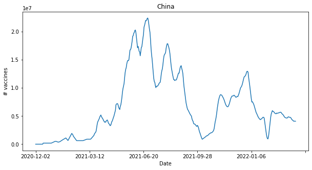

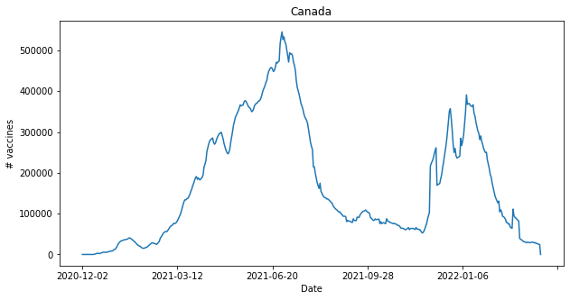

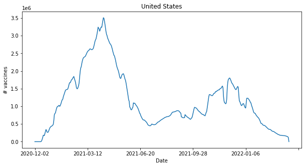

```python
### YOUR CODE HERE ###
import matplotlib.pyplot as plt
plt.rcParams["figure.figsize"] = (10,5)

def time_series (countries, dataset):
  for country in countries:
    # create time series plot
    dataset.loc[country].plot()
    plt.xlabel('Date')
    plt.ylabel('# vaccines')
    plt.title(country)
    plt.show()

time_series(['China', 'Canada', 'United States'], cases_raw) # plot the time-series for China and Canada before standardization
```

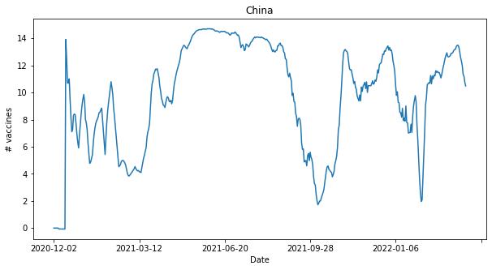

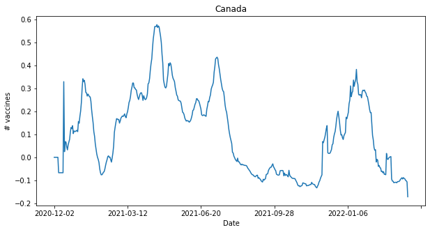

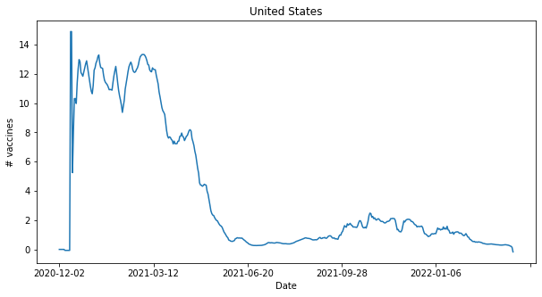

```python
# standardize data and plot
from sklearn.preprocessing import StandardScaler

cases_std = cases_raw.copy()
std_values = StandardScaler().fit_transform(cases_std.values) # standardize data
cases_std = pd.DataFrame(std_values, columns = cases_std.columns, index = cases_std.index) #create dataset

# Run the function in step 1 on the standardized dataset for the United States, China, and Canada
time_series(['China', 'Canada', 'United States'], cases_std)
```

# Part 2: Applying PCA [2 Marks]

1. Compute the covariance matrix of the dataframe. *Hint: The dimensions of your covariance matrix should be (483, 483).* **[0.25]**

Ans: see cell #4

1. Write a function `get_sorted_eigen(df_cov)` that gets the covariance matrix of dataframe `df` (from step 1), and returns sorted eigenvalues and eigenvectors using `np.linalg.eigh`. **[0.25]**

Ans: see cell #4

1. Show the effectiveness of your principal components in covering the variance of the dataset by superimposing the cumulative explained variance to a scree plot. **[0.25]**

Ans: see cell #4 and #5.

1. How many PCs do you need to cover 99% of the dataset's variance? Write an expression for this. **[0.25]** **[0.25]**

Ans: 8 priciple components are needed to cover 99% of the dataset's variance, the expression can be cumulative variance > 99, which is cumExpVar[i] >= 99 where i is the number of PCs needed.

1. Plot the first 16 principal components (Eigenvectors) as a time series (16 subplots, on the x-axis you have dates and on the y-axis you have the value of the PC element) . **[0.5]**

Ans: see cell #7.

1. Compare the first two PCs with the rest of them. Do you see any difference in their trend? **[0.5]**

Ans: For the first two PCs, they represent the trend of dropping from high values to lower values and then stays at the lower values. The other PCs do not have an obvious trend and are just fluctuating up and down since they are capturing very little information about the original dataset. The first two PCs capture most of the information from the original dataset so they have a clear trend of dropping in values.

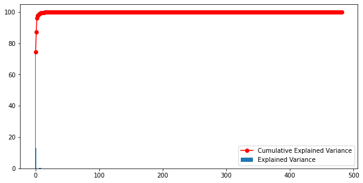

```python
### YOUR CODE HERE ###
import numpy as np
data_values = cases_std.values
cov_matrix = np.cov(data_values.T)
assert cov_matrix.shape == (483, 483), "ERROR: cov matrix shape mismatch."

# get eigenvalues/vectors
def get_sorted_eigen(df_cov):
  eigenValues, eigenVectors = np.linalg.eigh(df_cov)
  return eigenValues, eigenVectors

eigenValues, eigenVectors = get_sorted_eigen(cov_matrix)

# show scree plot
  #sort in decreasing orders
args = (-eigenValues).argsort()
eigenValues = eigenValues[args]
eigenVectors = eigenVectors[:, args]
  # make plot
eigValSum = sum(eigenValues)
expVar = [eigV/eigValSum*100 for eigV in eigenValues]
cumExpVar = np.cumsum(expVar)
plt.bar(range(483), expVar, label='Explained Variance')
plt.plot(cumExpVar, 'r-o', label='Cumulative Explained Variance')
plt.legend()
plt.show()
```

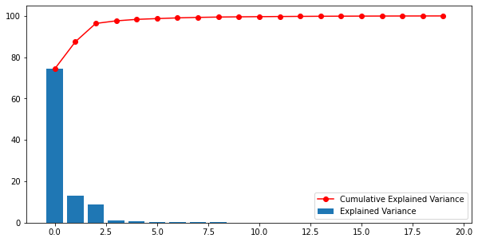

```python
plt.bar(range(20), expVar[0:20], label='Explained Variance')
plt.plot(cumExpVar[0:20], 'r-o', label='Cumulative Explained Variance')
plt.legend()
plt.show()
```

```python
# find #of PCs needed to cover 99% of variance
for i in range(20):
  if cumExpVar[i] >= 99:
    num_pc = i
    break
  else:
    pass

print('The number of PCs needed to cover >= 99% variance: ', num_pc +1)
```

```
The number of PCs needed to cover >= 99% variance:  8
```

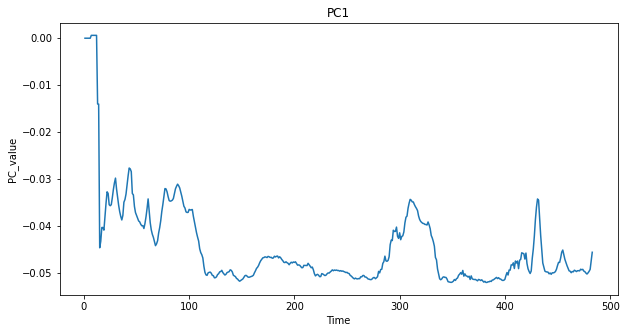

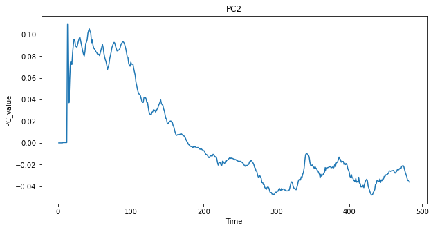

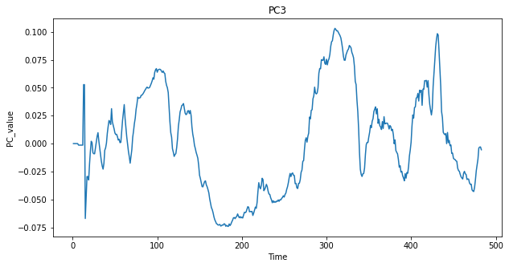

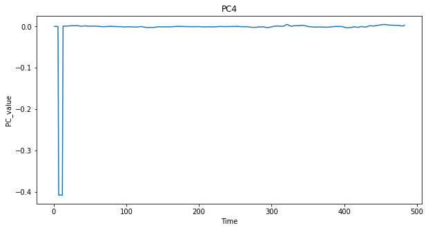

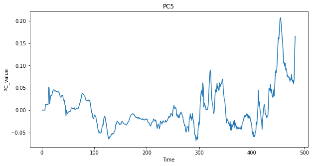

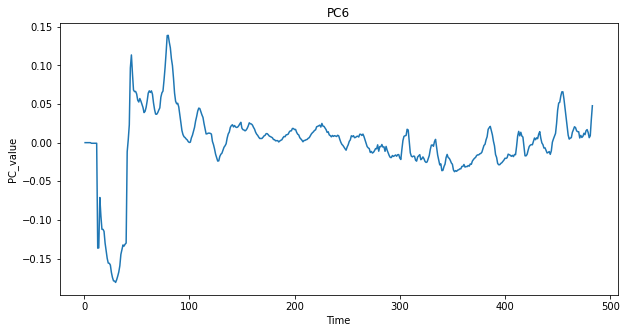

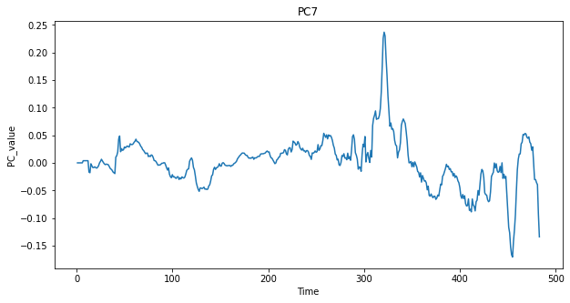

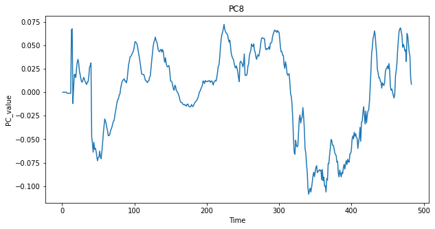

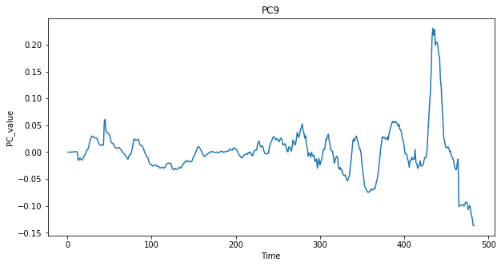

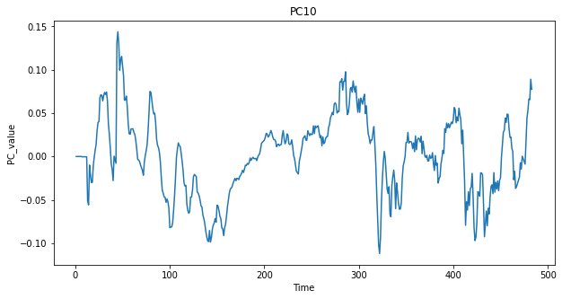

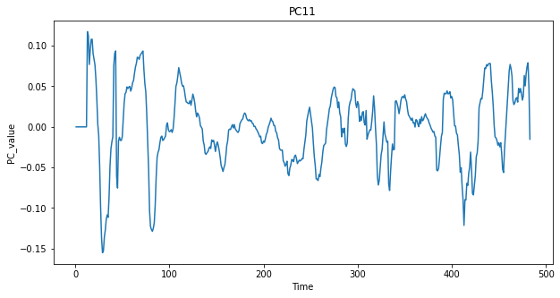

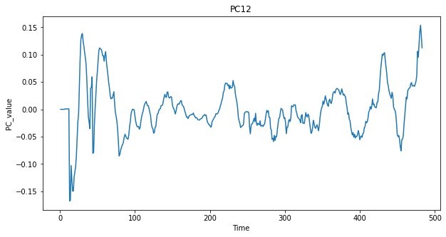

[4 more figures not shown]

```python
# Plot the first 16 principal components (Eigenvectors) as a time series
eigenVectors_16 = eigenVectors[:, 0:16].T
assert eigenVectors_16.shape == (16, 483), "ERROR: 16 eigenvectors not correct"

time_list = range(1, 484) # x-axis is date
for i in range (eigenVectors_16.shape[0]):
  plt.plot(time_list, eigenVectors_16[i])
  plt.xlabel('Time')
  plt.ylabel('PC_value')
  plt.title(f"PC{i+1}")
  plt.show()
  i += 1
```

# Part 3: Data reconstruction [3 Marks]

Create a function that:

- Accepts a country and the original dataset as inputs.
- Calls useful functions that you designed in previous parts to compute eigenvectors and eigenvalues.
- Plots 4 figures:
  1. The original time-series for the specified country. **[0.5]**

     Ans: see cell #8
  2. The residual error for your best reconstruction with respect to the original time-series. **[0.5]**
     - Hint: You are plotting the error that we have for reconstructing each day `(df - df_reconstructed)`. On the x-axis, you have dates, and on the y-axis, the residual error.

     Ans: see cell #8
  3. The RMSE of the reconstruction as a function of the number of included components (x-axis is the number of components and y-axis is the RMSE). Sweep x-axis from 1 to 10 (this part is independent from part 3.2.) **[1]**

Ans: see cell #8

Test your function using the `United States`, `Canada`, and `China` as inputs. **[0.5]**

Ans: see cell #9

```python
from sklearn.metrics import mean_squared_error

def plot_country_figures(original_df, country_name):
  #original time-series
  cases_raw.loc[country_name].plot()
  plt.xlabel('Date')
  plt.ylabel('# vaccines')
  plt.title(f'Original time series: {country_name}')
  plt.show()
  #The incremental reconstruction of the original (not standardized) time-series
  num_pcs = [1,2,4,8,16]
  reconstructions =[]
  for num in num_pcs:
    eigenvector_select = eigenVectors[:, 0:num] # select PC
    assert eigenvector_select.shape == (483, num), "Wrong eigenvector shape"
    projection = np.dot(cases_std.loc[country_name], eigenvector_select) #project on selected PCs
    ReconX = np.dot(projection, eigenvector_select.T) #reconstruction
    scaler = StandardScaler()
    scaler.fit_transform(original_df) # first fit and then inverse it
    Reconx_origin = scaler.inverse_transform(ReconX.reshape(1,-1))
    assert Reconx_origin.shape == (1,483), "reconstructed original data shape mismatch!"
    Reconx_origin = Reconx_origin.reshape(483) # reshape for plotting

    reconstructions.append(Reconx_origin)
  # plot the time-series
  i = 0
  for num in num_pcs:
    reconstruction = reconstructions[i]
    plt.plot(reconstruction, label=f'first {num} PCs')
    plt.title(f'Incremental reconstruction of original time series: {country_name}')
    plt.xlabel('Date')
    plt.ylabel('# vaccines')
    plt.legend()
    i += 1
  plt.show()

  # find the residual error for your best reconstruction (PC16) with respect to the original time-series.
  Reconx_origin_16 = reconstructions[-1]
  residual = original_df.loc[country_name].values - Reconx_origin_16
  plt.plot(residual)
  plt.title(f'Residual error with respect to original (16 PCs): {country_name}')
  plt.xlabel('Date')
  plt.ylabel("Residual")
  plt.show()

  #The RMSE of the reconstruction as a function of the number of included components
  reconstructions_RMSE = []
  for num in range(1,11):
    eigenvector_select = eigenVectors[:, 0:num] # select PC
    assert eigenvector_select.shape == (483, num), "Wrong eigenvector shape"
    projection = np.dot(cases_std.loc[country_name], eigenvector_select) #project on selected PCs
    ReconX = np.dot(projection, eigenvector_select.T) #reconstruction
    scaler = StandardScaler()
    scaler.fit_transform(original_df) # first fit and then inverse it
    Reconx_origin = scaler.inverse_transform(ReconX.reshape(1,-1))
    assert Reconx_origin.shape == (1,483), "reconstructed original data shape mismatch!"
    Reconx_origin = Reconx_origin.reshape(483) # reshape for plotting

    reconstructions_RMSE.append(Reconx_origin)
  assert len(reconstructions_RMSE) == 10, "reconstructions_RMSE length mismatch!"

  rmse_list = []
  for item in reconstructions_RMSE:
    rmse = mean_squared_error(original_df.loc[country_name].values, item) ** 0.5 # calculate RMSE
    rmse_list.append(rmse)
  assert len(rmse_list) == 10, "RMSE length mismatch!"
  plt.plot(rmse_list)
  plt.title(f'RMSE of reconstruction: {country_name}')
  plt.xlabel('Number of PCs')
  plt.ylabel("RMSE")
  plt.show()
```

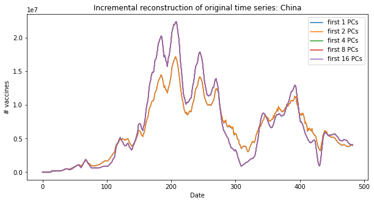

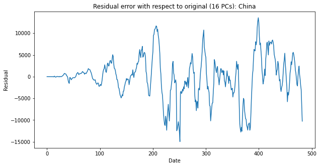

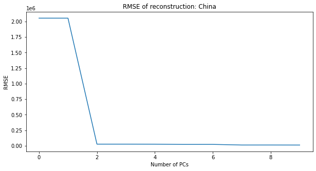

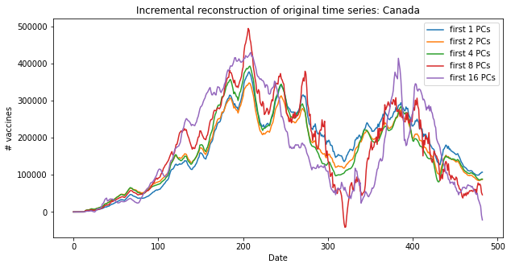

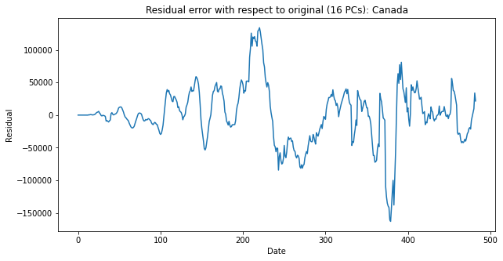

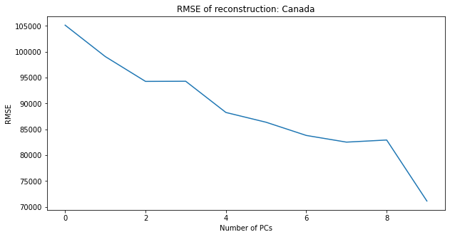

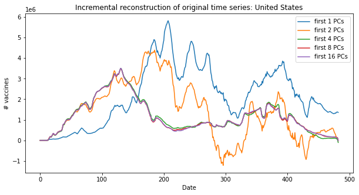

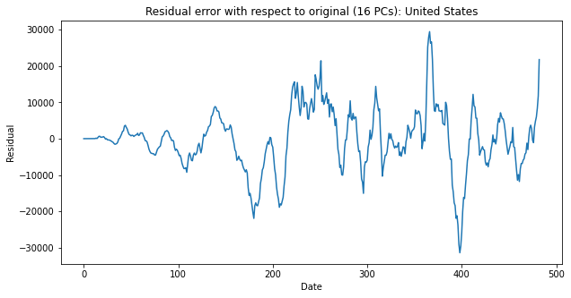

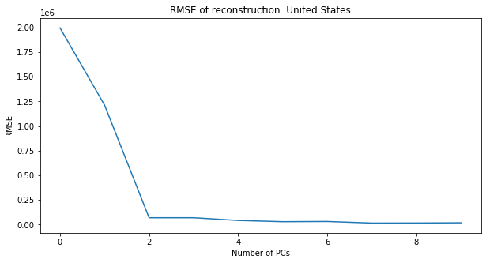

```python
countries = ['China', 'Canada', 'United States']
for country in countries:
  plot_country_figures(cases_raw, country)
```

[output not shown]

[output not shown]